# Reproducible Research: Peer Assessment 1

## Data

This assignment makes use of data from a personal activity monitoring device. This device collects data at 5 minute intervals through out the day. The data consists of two months of data from an anonymous individual collected during the months of October and November, 2012 and include the number of steps taken in 5 minute intervals each day.

The data for this assignment can be downloaded from the course web site:

- Dataset: [Activity monitoring data](https://d396qusza40orc.cloudfront.net/repdata%2Fdata%2Factivity.zip) [52K]

The variables included in this dataset are:

- **steps**: Number of steps taking in a 5-minute interval (missing values are coded as `NA`)
- **date**: The date on which the measurement was taken in YYYY-MM-DD format
- **interval**: Identifier for the 5-minute interval in which measurement was taken

The dataset is stored in a comma-separated-value (CSV) file and there are a total of 17,568 observations in this dataset.

## Setting the stage

First, we will remove all variables from the environment and choose the POSIX locale.

```r
rm(list=ls(all=TRUE))
Sys.setlocale(category = "LC_ALL", locale = "C")
```

## Loading and preprocessing the data

Next, we load the data into a dataframe and inspect its overall structure.

```r
activity.df <- read.csv("activity.csv", header = TRUE)
```

```r
str(activity.df)
```

```
## 'data.frame':    17568 obs. of  3 variables:
##  $ steps   : int  NA NA NA NA NA NA NA NA NA NA ...
##  $ date    : Factor w/ 61 levels "2012-10-01","2012-10-02",..: 1 1 1 1 1 1 1 1 1 1 ...
##  $ interval: int  0 5 10 15 20 25 30 35 40 45 ...
```

## What is the mean total number of steps taken per day?

For this part of the assignment, we will ignore the missing values in the dataset.

### Making a histogram of the total number of steps taken each day

We use the `dplyr` library to summarise the dataframe.

```r
library(dplyr)
```

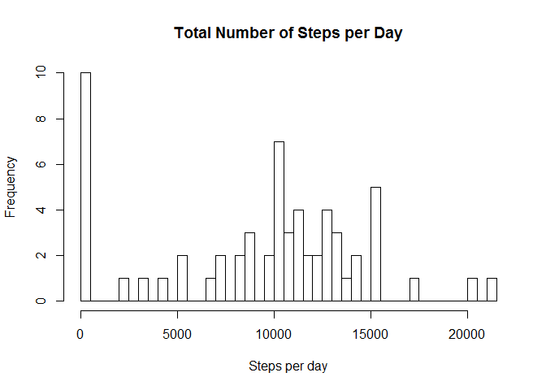

```r
total.per.day <- summarise(group_by(activity.df, date),
                           steps = sum(steps, na.rm = TRUE))
hist(total.per.day$steps,
     breaks = 40,
     main = "Total Number of Steps per Day",
     xlab = "Steps per day")
```

### Calculating and report the **mean** and **median** total number of steps taken per day

We now calculate the **mean** and **median** over the total number of steps.

```r
mean.per.day <- round(mean(total.per.day$steps), 3)
median.per.day <- round(median(total.per.day$steps), 3)
```

```r
mean.per.day
```

```
## [1] 9354.23
```

```r
median.per.day
```

```
## [1] 10395
```

Then we supplement the histogram with the **mean** and **median** values.

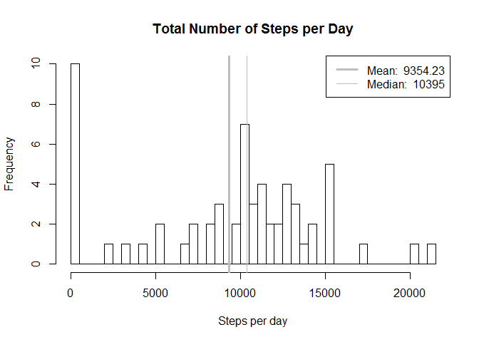

```r
hist(total.per.day$steps,
     breaks = 40,
     main = "Total Number of Steps per Day",
     xlab = "Steps per day")

abline(v = mean.per.day, lwd = 3, col = "grey")
abline(v = median.per.day, lwd = 1, col = "grey")

legend("topright", lwd = c(3, 1), col = "grey",
       legend = c(paste("Mean: ", mean.per.day),
                  paste("Median: ", median.per.day))
       )
```